# What makes you Happy?

Yang Yang (yy2819)

Reminder: some codes are hidden from the html report.  
To see the full code, please see the “FinalReport.Rmd”.  
If you wanna run whole code, turn all chunks’ eval option into TRUE

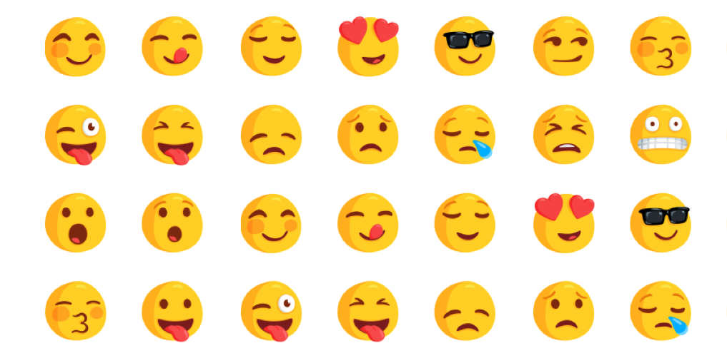

This project aims to analysis what makes people happy, from the data collected in [HappyDB](https://rit-public.github.io/HappyDB/)  
HappyDB is a corpus of 100,000 crowd-sourced happy moments via Amazon’s Mechanical Turk. The survey question is:

```
What made you happy today?  Reflect on the past {24 hours|3 months}, and recall three actual events that happened to you that made you happy.  Write down your happy moment in a complete sentence.
Write three such moments.
Examples of happy moments we are NOT looking for (e.g events in distant past, partial sentence):
    - The day I married my spouse
    - My Dog
```

You can read more about it on https://arxiv.org/abs/1801.07746

### Step 0 - Load the data and pre-process them

The *text_processing.Rmd*(provided by ) clean the text by converting all the letters to the lower case, and removing punctuation, numbers, empty words, extra white space, and stemming words, removing stop words, and choosing the words with highest frequency for each moments.

*However, the original text_processing.Rmd* has some weakness, which didn’t transform different verb tense to its simple tense very well.

```r
# Load Data (Download if not exists)
if(!file.exists("../data/cleaned_hm.csv")){
  urlfile<-'https://raw.githubusercontent.com/rit-public/HappyDB/master/happydb/data/cleaned_hm.csv'
  hm_data <- read_csv(urlfile)
}
# Process data if the processed_moments not exists
if(!file.exists("../output/processed_moments.csv")){
  hm_data = read_csv("../data/cleaned_hm.csv")
  source(purl("../lib/Text_Processing.Rmd",output=tempfile()))
}
if(!file.exists("../data/demographic.csv")){
  urlfile<-'https://raw.githubusercontent.com/rit-public/HappyDB/master/happydb/data/demographic.csv'
  demo_data <- read_csv(urlfile)
}
demo_data=read_csv("../data/demographic.csv")
hm_data=read_csv("../output/processed_moments.csv")
```

We also combine the happy moments data with the worker’s demographic data.  
To make our research more specific, we filter out some special data like other gender, NA gender.  
[Code hided]

# Basic Exploration of Data

## Description

First, let’s have a quick look at several data examples:

| wid | original_hm | gender | marital | parenthood | reflection_period | age | country | ground_truth_category | text | count | originalcount |
| --- | --- | --- | --- | --- | --- | --- | --- | --- | --- | --- | --- |
| 2053 | I went on a successful date with someone I felt sympathy and connection with. | m | single | n | hours_24 | 35 | USA | NA | successfully date sympathy connected | 4 | 14 |
| 2 | I was happy when my son got 90% marks in his examination | m | married | y | hours_24 | 29.0 | IND | NA | son marks examination | 3 | 12 |
| 1936 | I went to the gym this morning and did yoga. | f | married | y | hours_24 | 30 | USA | NA | gym morning yoga | 3 | 10 |
| 206 | We had a serious talk with some friends of ours who have been flaky lately. They understood and we had a good evening hanging out. | f | married | n | hours_24 | 28 | DNK | bonding | talked friend flaky understood evening hang | 6 | 25 |
| 45 | I meditated last night. | m | single | n | hours_24 | 23 | IND | leisure | meditation night | 2 | 4 |
| 195 | I made a new recipe for peasant bread, and it came out spectacular! | m | single | n | hours_24 | 30 | USA | NA | recipe peasant bread spectacular | 4 | 13 |

We can see, that demographic data include their gender, marital, parentihood, age, country, etc. And the original happy moments data consists of 1 sentence in each moment.  
For detail Description, see [HappyDB](https://rit-public.github.io/HappyDB/)

## Word Count

We can perform a statistical analysis based on the number of words.

```r
summary(hm_data$originalcount)
```

```
##    Min. 1st Qu.  Median    Mean 3rd Qu.    Max.
##    2.00    9.00   14.00   18.31   21.00 1155.00
```

So strange, how can the moments sentence be so long as 1155? Let’s see those long sentence with length > 1000

```
## [1] "This is the second essay in a two-part series about my journey to visit the Taj Mahal. Read the first part for the whole story.\r\n\r\nA\r\nGRA, Uttar Pradesh, India a As soon as my train to Agra leaves fro"
## [2] "This is the second essay in a two-part series about my journey to visit the Taj Mahal. Read the first part for the whole story.\r\n\r\nA\r\nGRA, Uttar Pradesh, India -- As soon as my train to Agra leaves fr"
## [3] "My much awaited desired prolonged Velankanni trip.\r\n\r\nOne of the greatest pleasures of being in Chennai is your proximity to a lot of one day getawaysa| and nothing more exciting than planning a trip."
```

Oh, I see, these people just ignore the requirement of the tasks! **They wrote essays about their happy moments!!** OK, just exclude them from the data. No way to let them increase their weight by 100 times huh.

```r
hm_data=hm_data[hm_data$originalcount<500,]
summary(hm_data$originalcount)
```

```
##    Min. 1st Qu.  Median    Mean 3rd Qu.    Max.
##    2.00    9.00   14.00   18.16   21.00  483.00
```

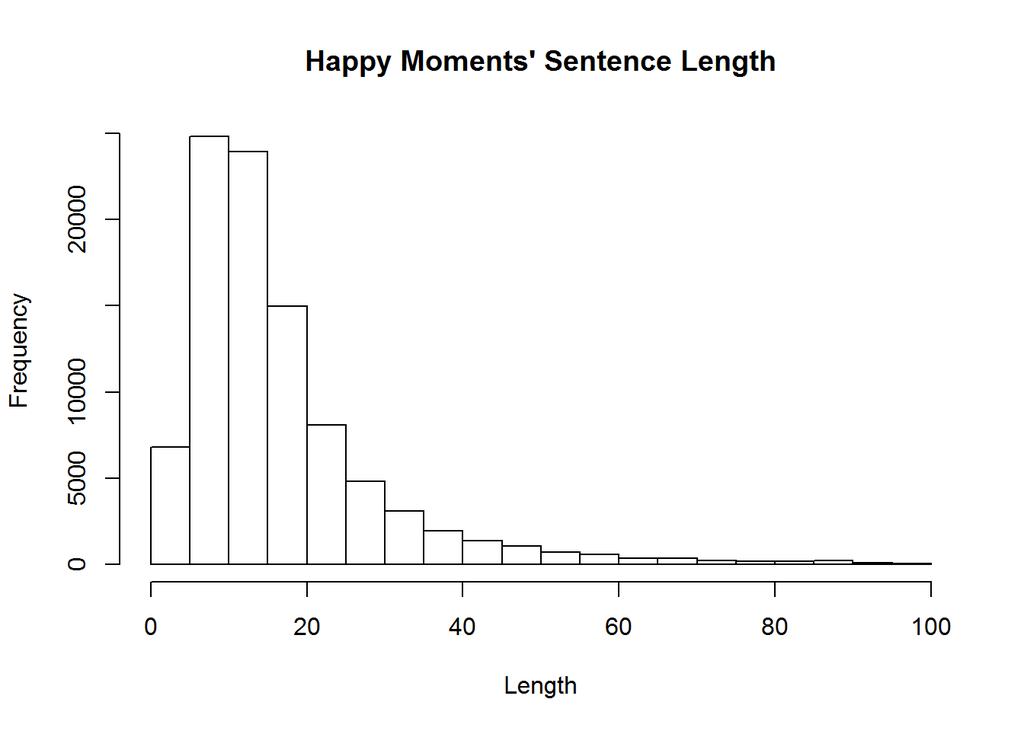

```r
hist(hm_data$originalcount[hm_data$originalcount<100],main="Happy Moments' Sentence Length",xlab = "Length")
```

Most of the happy moments are short sentences, as expected!  
Some happy moments even have only two words.

## Happiness Doesn’t Depend on Demographic Difference

We tried to find out whether **Demographic Difference** influence Happiness.

```r
sentiment.values.v <- get_sentiment(hm_data$text[hm_data$gender=='m'], method="syuzhet")
summary(sentiment.values.v)
```

```
##    Min. 1st Qu.  Median    Mean 3rd Qu.    Max.
## -4.3000  0.0000  0.5500  0.6621  1.1000 18.9500
```

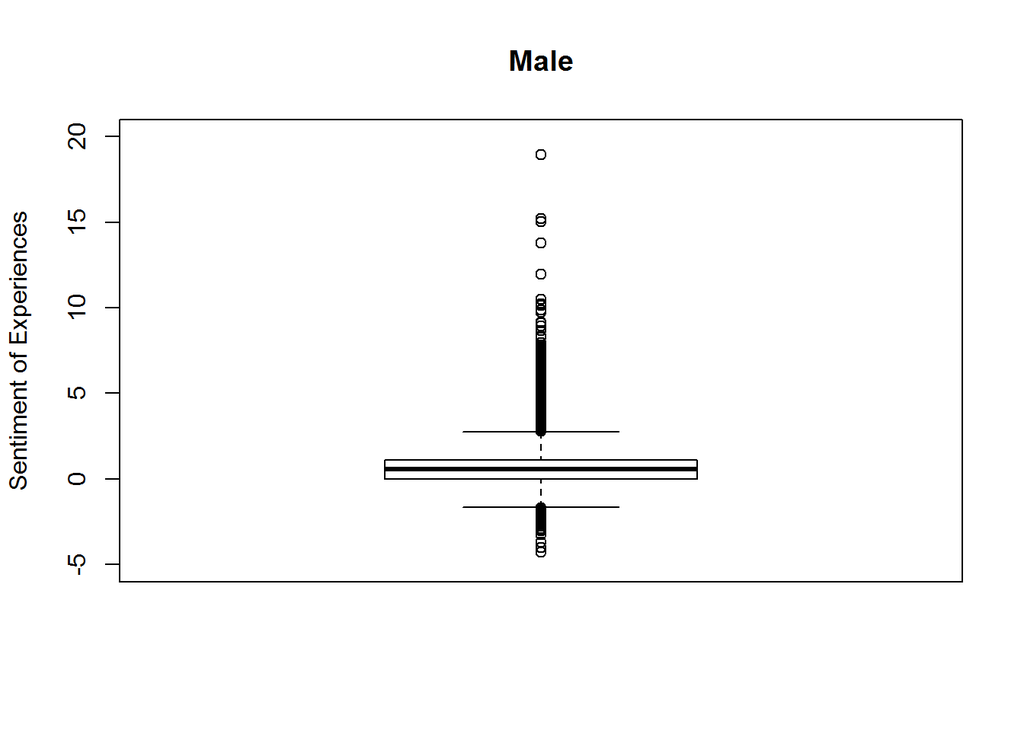

```r
boxplot(sentiment.values.v, ylim=c(-5, 20), main="Male", ylab="Sentiment of Experiences")
```

```r
p <- plot_ly(type = 'box') %>%
    add_boxplot(y = sentiment.values.v, boxpoints = 'outliers',
              marker = list(color = 'rgb(7,40,89)'),
              line = list(color = 'rgb(7,40,89)'),
              name = "All Points")
```